# PH4199 Project: COVID-19 and Vaccines

This was my submission for my Computational Physics Module Final Project, in 2021, taught by Asst Prof. Marco Battiato. This is a direct conversion of my jupyter notebook to a HTML file. At some point I do intend to come back to clean up the citations on this file.

I would like to highlight that the code for the Runge-Kutta 4 and Nelder-Mead algorithms used in this project were not originally written by me. Marco provided the code for those two algorithms during his class, and we were allowed to employ them in our project submission. Big thank you to Marco for his additional assistance during this project as well!

1. Project Goal

#### Theory & Approach

1. Original SEIR Model
2. Modified SEIR Model
   1. Vaccination Rollout
   2. Only Inclusion of Deaths from Virus
   3. Different Age Groups
   4. Modified Differential Equations to Solve
3. Values for Variables
   1. Constants
   2. Population Size, Susceptibility and Infection Fatality Rate (IFR)
   3. Contact Rate (Contact Matrix)
4. References

#### Implementation & Results

1. Part 1: Vaccines vs No Vaccines
   1. Case 1: No vaccines, constant susceptibility across age groups
   2. Case 2: Vaccines, constant susceptibility across age groups
   3. Comparing Case 1 and 2
2. Part 2: Optimisation
   1. Attempted Approach 1: Bounded Reflection and Expansion Steps
   2. Attempted Approach 2: Modified Function with Penalty
   3. Results and Comparing Cases

## Project Goal

- Model the influence of vaccinations on limiting COVID-19 spread and deaths
- Solve a **modified** Susceptible Exposed Infectious Recovered (SEIR) model's differential equations using **Runge-Kutta 4** to plot a dependence of infection against time for both vaccinated and unvaccinated communities.
- Optimize the vaccination strategy across age groups to minimize deaths due to COVID using the **Nelder-Mead algorithm**, assuming we have limited vaccines (only enough for 20% of population)

## Original Susceptible Exposed Infectious Recovered (SEIR) Model

In this basic SEIR model [1, 2], the different groups of people are represented as:

- S: Susceptible individuals (able to contract the disease)
- E: Exposed individuals (those who have been infected but are not yet infectious)
- I: Infections individuals (has the disease)
- R: Recovered individuals
- N: Total number of individuals

Assumptions of this model:

- Birth rate = death rate, such that N remains constant
- Recovered individuals are forever immune
- $1/\sigma$: mean time interval between when an individual is infected by a pathogen and when they become infectious (incubation period)
- $1/\gamma$: mean infectious period
- $\beta(t)$: contact rate
- $\mu$: birth rates
- $\nu$: death rates

In this model, the equations to solve are:

\begin{equation} \begin{split} \frac{dS}{dt} &= \mu N - \nu S - \frac{\beta SI}{N} \\ \frac{dE}{dt} &= \frac{\beta SI}{N} - \nu E -\sigma E \\ \frac{dI}{dt} &= \sigma E - \gamma I - \nu I \\ \frac{dR}{dt} &= \gamma I - \nu R \end{split} \end{equation}

## Modified SEIR Model

These equations must be modified in our case to allow for [3]:

- Vaccine Rollout
- Exclusion of natural deaths and births, (i.e. only include deaths from virus)
- Different age groups

### Vaccination Rollout

In the simplest model, vaccines and vaccination rollouts have the following assumptions:

- All-or-nothing vaccine model is used: i.e. a fraction of vaccinated individuals gain complete immunity against exposure and infection
- Pre-transmission vaccination scenario: available vaccines distributed at initial timestep, prior to epidemic
- Not everyone is eligible/willing to be vaccinated (vaccine hesitancy)

To modify the model to include vaccination rollout:

- Vaccinated individuals are a percentage of Susceptible individuals who are now vaccinated **AND** gain immunity from the virus. They are also not infectious.
- While some individuals may be vaccinated, they may not gain immunity. This percentage of individuals will form the susceptible group with those who cannot or do not want to be vaccinated

### Only Inclusion of Deaths from Virus

To assess how vaccinations can influence death rates due to the virus alone, the model can be modified such that natural deaths and births are excluded from the model. This can be seen as the natural birthrate being equal to the natural death rate. As such, the strategy:

- Set all $\nu$ and $\mu$ to be equal to 0, except for the $\nu$ in the differential equation for the infected individuals (infection fatality rate)
- Introduce N varying with t, rather than a constant value: equivalent to the number of deaths due to infection

This model can be easily tweaked to also include birth rates by having a non-zero value of $\nu$ and altering the differential for N to include birthrates.

### Different Age Groups

We have 16 bins of different age groups, each with the range of 5 years. Age groups will affect:

- Contact rate between individuals within a group and between groups
- Death rates (some groups have higher mortality rates)
- Susceptibility

Different age groups can be achieved by:

- Altering and indexing the equations, with $i$ such that each age group has a 'set' of differential equations that also depend on one another

The relative susceptibility is how susceptible each age group is to being exposed to the virus. Each age group will differ on the susceptibility, giving rise to higher risk age groups. This will affect the differentials $dS/dt$ and $dE/dt$ for each age group $i$, and can be achieved by:

- Adding a factor of $u_i$ (relative susceptibility of each age group) to the term corresponding to the exposed individuals

### Final Modified Differential Equations to Solve

Considering the above modifications, the final equations to solve for each age group $i$ in contact with age group $j$ are:

\begin{equation} \begin{split} \frac{dN_i}{dt} &= -\nu_i I_i \\ \frac{dS_i}{dt} &= - u_i \cdot S_i \sum_j \frac{\beta_{ij} I_j}{N_j} \\ \frac{dE_i}{dt} &= u_i \cdot S_i \sum_j \frac{\beta_{ij} I_j}{N_j} -\sigma E_i \\ &= -\frac{dS_i}{dt} -\sigma E_i \\ \frac{dI_i}{dt} &= \sigma E_i - \gamma I_i - \nu_i I_i \\ &= \sigma E_i - \frac{dR_i}{dt} + \frac{dN_i}{dt} \\ \frac{dR_i}{dt} &= \gamma I_i \end{split} \end{equation}

## Values for Variables

To begin to solve our differential equations with RK4 (non-adaptive time-stepping), we must first source for the values of the constants. Also note that each age group has their own values for contact rates with other age groups, ($\beta_{ij}$) that must be sourced. The values of population size and contact rates have been chosen to be based in Singapore.

### Constants

| Variable | Description | Value | Reference |
| --- | --- | --- | --- |
| $1/\sigma$ | Incubation period | 3 days | [3] |
| $1/\gamma$ | Infectious period | 5 days | [3] |
| $N_i$ | Number of individuals in each age group (population size) | Country dependent, see below | [6] |
| $u_i$ | Relative susceptibility to infection for age group $i$ individuals | Otherwise, age dependent, see below | [7] |
| $\nu _i$ | Infection fatality rate (IFR) for age group $i$ | Age dependent, see below | [4] |
| $\beta_{ij}$ | Contact rate (contact matrix) | Country dependent, see below | [5] |
| $S_i$ | Number of susceptible individuals in each age group | 30% of $N_i$ for vaccinated scenario, 100% for un-vaccinated scenario | [3] |
| $I_i^0$ | Initial number of infected individuals in each age group | 1 | [3] |
| $t^0$ | Initial time | 0 days | - |
| $t^f$ | Final time | 100 days | - |

### Population Size, Susceptibility and Infection Fatality Rate (IFR)

The IFR has been modelled to be:

$$lg(\text{IFR}) = −3.27 + 0.0524 \cdot \text{age} \cdot (0.07)(0.0013)$$

Since the equation given for IFR is dependent on age, rather than age group, the IFR for each age group can be taken to be the average of the IFR of all the ages within the selected age group. The values for Population size, IFR, and relative susceptibility is given as follows:

| Age Group | Age Index, $i$ | Total Population in Age Group | IFR, $\nu_i$ | Rel. Susceptibility $u_i$ |
| --- | --- | --- | --- | --- |
| 0-4 | 1 | 183080 | 0.03800679 | 0.4 |
| 5-9 | 2 | 198740 | 0.038007696 | 0.4 |
| 10-14 | 3 | 206390 | 0.038008602 | 0.38 |
| 15-19 | 4 | 215230 | 0.038009508 | 0.38 |
| 20-24 | 5 | 244540 | 0.038010414 | 0.79 |
| 25-29 | 6 | 287000 | 0.038011321 | 0.79 |
| 30-34 | 7 | 297800 | 0.038012227 | 0.86 |
| 35-39 | 8 | 299520 | 0.038013133 | 0.86 |
| 40-44 | 9 | 299290 | 0.038014039 | 0.8 |
| 45-49 | 10 | 311740 | 0.038014946 | 0.8 |
| 50-54 | 11 | 296070 | 0.038015852 | 0.82 |
| 55-59 | 12 | 305830 | 0.038016759 | 0.82 |
| 60-64 | 13 | 284630 | 0.038017665 | 0.88 |
| 65-69 | 14 | 229400 | 0.038018571 | 0.88 |
| 70-74 | 15 | 170010 | 0.038019478 | 0.74 |
| 75-79 | 16 | 90990 | 0.038020384 | 0.74 |

Since they are all close in values, in the implementation, the IFR was taken to be constant for all age groups with a value of $\nu = 0.03801$. Also, in the implementation, the population numbers have been scaled to be in 1000s, rather than the raw value. I.e. the raw population numbers are divided by 1000.

### Contact Rate (Contact Matrix)

We have 16 age bins from 0 to 80, each with a range of 5 years. Thus, we will have 16 contact matrices for an inidividual in age group index $i$ of the form:

\begin{equation} \beta_{i} = \begin{bmatrix} \beta_{i1} \\ \vdots \\ \beta_{ij} \\ \vdots \\ \beta_{i16} \end{bmatrix} \end{equation}

**Important Note:** The synthetic/generated contact matrix for Singapore, sourced from [5] already accounts for the factor of $1/N_j$ as the values inside the matrix are the mean number of contacts *per individual*. Thus, in our implementation, we no longer have to include the factor of $1/N_j$.  
Thus, our implementation will simply involve the dot product of the contact matrix for age group $i$ with the matrix containing the number of infected individuals per age group $j$: \begin{equation} \sum_j \beta'_{ij} \frac{I_j}{N_j} = \sum_j \beta_{ij}I_j = \begin{bmatrix} \beta_{i1} \\ \vdots \\ \beta_{ij} \\ \vdots \\ \beta_{i16} \end{bmatrix} \cdot \begin{bmatrix} I_{1} \\ \vdots \\ I_{j} \\ \vdots \\ I_{16} \end{bmatrix} \end{equation}

## References

1. https://sites.me.ucsb.edu/~moehlis/APC514/tutorials/tutorial_seasonal/node4.html
2. https://docs.idmod.org/projects/emod-hiv/en/latest/model-seir.html
3. https://science.sciencemag.org/content/sci/suppl/2021/01/19/science.abe6959.DC1/abe6959-Bubar-SM.pdf
4. https://link.springer.com/article/10.1007/s10654-020-00698-1
5. https://github.com/kieshaprem/synthetic-contact-matrices
6. https://www.statista.com/statistics/624913/singapore-population-by-age-group/
7. https://www.nature.com/articles/s41591-020-0962-9

## Part 1: Vaccines vs No Vaccines

We import the algorithm for Runge-Kutta 4 (non-adaptive time stepping) and initialize our constants as well as contact matrices. We choose non-adaptive time-stepping so we can examine the movement of the virus on a day-to-day timescale.

**Note:** We are initializing our numbers in 1000s. Thus, we need to divide our beta values by 1000, as it is a matrix containing the number of close contacts (in each age group) *per individual* and therefore must be rescaled to be in 1000s. IFR ($\nu$), $\sigma$ and $\gamma$ do not have to be scaled as they are ratios.

```python
import numpy as np
import matplotlib.pyplot as plt


def rungeKutta4(operator, initCond, initTime, finalTime, nSteps):
    '''
    Solves an ODE of type dy(t)/dt = f(t,y(t)) using Runge Kutta 4

    Parameters
        ----------
        operator  : function
            function of time (: float) and the y (: float / numpy.array)
            NOTICE: it must a function of both variables even if not explicitly dependent on both
            For instance:   lambda t, y: np.sin(y)    and not     lambda y: np.sin(y)
        initCond  : float / numpy.array
            initial condition, i.e. y(t = initial time)
        initTime  : float
            initial time
        finalTime : float
            final time of the simulation
        nSteps    : int
            number of steps to take

    Returns
        ----------
        times : numpy.array
            numpy array of all the calculated times
        solution : numpy.array
            numpy array of all the calculated y's
    '''

    dt = (finalTime - initTime)/nSteps
    times = np.linspace(initTime, finalTime, nSteps+1)
    solut = [initCond]
    for t in times[:-1]:
        k1 = dt * operator(t, solut[-1])
        k2 = dt * operator(t + dt/2, solut[-1] + k1/2 )
        k3 = dt * operator(t + dt/2, solut[-1] + k2/2 )
        k4 = dt * operator(t + dt, solut[-1] + k3)
        solut.append(solut[-1] + (k1 + 2*k2 + 2*k3 + k4)/6 )

    return times, np.array(solut)
```

```python
# General Constants
sigma = 0.333; gamma = 0.2

# IFR
nu = 0.03801

# Population Numbers (in 1000s)
N1 = 183.08; N2 = 198.74; N3 = 206.39; N4 = 215.23;
N5 = 244.54;  N6 = 287;  N7 = 297.8;  N8 = 299.52;
N9 = 299.29;  N10 = 311.74;  N11 = 296.07;  N12 = 305.83;
N13 = 284.63;  N14 = 229.4;  N15 = 170.01;  N16 = 90.99;

# Relative Susceptibility
relSuscep = np.array([0.4, 0.4, 0.38, 0.38, 0.79, 0.79, 0.86, 0.86, 0.8, 0.8, 0.82, 0.82, 0.88, 0.88, 0.74, 0.74])

# Contact Matrices
beta1  = [2.1784, 1.36569, 0.18842, 0.15675, 0.28198, 0.66082, 0.92195, 0.97792, \
          0.57194, 0.33149, 0.52002, 0.87944, 1.11307, 0.76427, 0.27734, 0.1919]
beta2  = [0.75359, 7.83843, 2.29811, 0.31465, 0.21479, 0.26973, 0.74392, 1.25102, \
          1.04238, 0.6505, 0.50897, 0.86446, 1.01762, 1.08399, 0.72988, 0.24254]
beta3  = [0.30626, 0.92481, 11.83069, 3.52713, 0.28484, 0.1516, 0.49275, 0.87573, \
          1.29983, 0.87918, 0.70424, 0.55568, 0.65718, 0.83189, 0.55993, 0.3273]
beta4  = [0.19743, 0.20643, 0.78558, 11.03327, 1.75214, 0.54222, 0.27659, 0.47502, \
          0.83401, 1.19502, 0.9157, 0.73185, 0.65826, 0.46956, 0.50862, 0.2577]
beta5  = [0.30232, 0.20123, 0.2724, 1.03551, 3.62432, 1.92999, 0.96849, 0.70404, \
          0.92996, 1.00897, 1.17577, 0.93361, 0.75208, 0.5379, 0.18334, 0.10722]
beta6  = [0.56161, 0.50507, 0.39781, 0.60478, 1.77814, 3.81797, 1.98813, 1.57925, \
          1.45127, 1.21461, 1.62103, 1.58359, 1.27004, 0.8172, 0.34209, 0.11079]
beta7  = [0.88059, 0.76619, 0.49208, 0.5243, 1.14291, 2.14389, 3.16952, 1.99095, \
          1.91166, 1.46973, 1.48429, 1.78333, 1.48138, 1.0981, 0.32443, 0.18074]
beta8  = [0.84484, 0.91604, 0.81413, 0.74422, 0.97758, 1.66242, 2.12001, 3.34883, \
          2.16003, 1.68564, 1.42981, 1.38201, 1.54476, 0.97222, 0.55079, 0.23061]
beta9  = [0.4287, 0.82498, 1.02186, 0.85466, 0.89981, 1.40643, 1.61863, 2.2879, \
          3.21221, 1.85407, 1.88826, 1.54278, 1.38242, 0.99561, 0.59236, 0.2302]
beta10 = [0.28131, 0.44998, 0.68439, 0.97148, 1.14891, 1.16634, 1.29027, 1.49912, \
          1.96595, 2.46033, 2.0768, 1.33446, 1.20506, 0.63708, 0.45801, 0.24587]
beta11 = [0.29602, 0.33143, 0.414, 0.51304, 0.81358, 1.14138, 1.01991, 1.12736, \
          1.36622, 1.42115, 2.18137, 1.65098, 1.15865, 0.74657, 0.37365, 0.24289]
beta12 = [0.24087, 0.20394, 0.24028, 0.26162, 0.42712, 0.626, 0.77738, 0.67522, \
          0.58992, 0.72094, 1.17085, 1.91923, 1.36833, 0.7767, 0.30959, 0.1642]
beta13 = [0.17015, 0.16797, 0.13213, 0.12762, 0.20977, 0.33333, 0.42578, 0.47077, \
          0.45357, 0.3806, 0.54045, 0.89476, 1.53743, 0.78765, 0.55943, 0.13264]
beta14 = [0.12892, 0.10835, 0.0902, 0.07499, 0.0869, 0.12256, 0.17673, 0.26168, \
          0.2339, 0.18944, 0.20734, 0.36263, 0.639, 1.098, 0.52162, 0.18852]
beta15 = [0.08596, 0.05349, 0.06258, 0.03561, 0.08688, 0.05098, 0.07574, 0.14755, \
          0.1501, 0.14579, 0.13769, 0.17384, 0.38246, 0.38518, 0.69555, 0.17295]
beta16 = [0.04502, 0.03655, 0.05717, 0.02463, 0.06951, 0.03377, 0.07045, 0.05995, \
          0.06941, 0.12563, 0.11215, 0.12401, 0.15911, 0.18286, 0.23697, 0.16573]
# we initialize a beta with nested arrays to be used in our functions for the differential equations later on
beta = np.array([beta1, beta2, beta3, beta4, beta5, beta6, beta7, beta8, \
                 beta9, beta10, beta11, beta12, beta13, beta14, beta15, beta16]) / 1000
```

We also standardize the `xvec` to be passed through the RK4 solver to be as follows:

$$\begin{bmatrix} I_1 & \ldots & I_{16} & S_1 & \ldots & S_{16} & E_1 & \ldots & E_{16} & R_1 & \ldots & R_{16} & N_1 & \ldots & N_{16} \end{bmatrix}$$

**Indices for numpy array:** $$\begin{bmatrix} 0 & \ldots & 15 & 16 & \ldots & 31 & 32 & \ldots & 47 & 48 & \ldots & 63 & 64 & \ldots & 79 \end{bmatrix}$$

And thus, the numpy array of differential equations, `operator`, will follow the same order for continuity. From this, we can write our 80 differential equations that will be the components of `operator`. To speed up the process, we can do this by creating functions for each differential equation that takes in the input of age group index $i$, `xvec` and time, $t$.

```python
def dN(i, xvec, t):
    '''
    Differential equation for the total number of individuals in age group i.

    Parameters
    ---
    i    : int
           age group index
    xvec : numpy array
           the array of solution values from the previous timestep
    t    : float
           time in days

    Returns
    ---
    value : float
            function value of dN at time t
    '''

    value = - nu * xvec[i-1]
    return value


def dS(i, xvec, t):
    '''
    Differential equation for the number of susceptible individuals in age group i.

    Parameters
    ---
    i           : int
                  age group index
    xvec        : numpy array
                  the array of solution values from the previous timestep
    t           : float
                  time in days

    Returns
    ---
    value : float
            function value of dS at time t
    '''

    value = -xvec[15+i] * np.dot(beta[i-1], xvec[0:16]) * relSuscep[i-1]
    return value

def dE(i, xvec, t):
    '''
    Differential equation for the number of exposed individuals in age group i.

    Parameters
    ---
    i           : int
                  age group index
    xvec        : numpy array
                  the array of solution values from the previous timestep
    t           : float
                  time in days

    Returns
    ---
    value : float
            function value of dE at time t
    '''

    value = xvec[15+i] * np.dot(beta[i-1], xvec[0:16]) * relSuscep[i-1] - sigma * xvec[31+i]
    return value

def dI(i, xvec, t):
    '''
    Differential equation for the number of infectious individuals in age group i.

    Parameters
    ---
    i           : int
                  age group index
    xvec        : numpy array
                  the array of solution values from the previous timestep
    t           : float
                  time in days

    Returns
    ---
    value : float
            function value of dI at time t
    '''

    value = sigma * xvec[31+i] - gamma * xvec[i-1] - nu * xvec[i-1]
    return value

def dR(i, xvec, t):
    '''
    Differential equation for the number of recovered individuals in age group i.

    Parameters
    ---
    i           : int
                  age group index
    xvec        : numpy array
                  the array of solution values from the previous timestep
    t           : float
                  time in days

    Returns
    ---
    value : float
            function value of dR at time t
    '''

    value = gamma * xvec[i-1]
    return value
```

### Case 1: No vaccines

As a baseline, we run the simulation for the the case where no vaccines have been rolled out, with different susceptibilities for each age group implemented.

#### Initial Conditions

- $I_i^0 =1/1000$ (seeded with 1 exposed person in each group, but note the numbers are in 1000s)
- $S_i^0 = N_i^0 - E_i^0 - I_i^0$ (everyone is equally susceptible and unvaccinated)
- $E_i^0 = 0$
- $R_i^0 = 0$
- $t^0=0$

```python
# Inputs: Time
initTime  = 0
finalTime = numSteps = 100

# Inputs: Operator
operator  = lambda t, xvec: np.array([dI(1, xvec, t), dI(2, xvec, t), dI(3, xvec, t), dI(4, xvec, t), \
                                      dI(5, xvec, t), dI(6, xvec, t), dI(7, xvec, t), dI(8, xvec, t), \
                                      dI(9, xvec, t), dI(10, xvec, t), dI(11, xvec, t), dI(12, xvec, t), \
                                      dI(13, xvec, t), dI(14, xvec, t), dI(15, xvec, t), dI(16, xvec, t), \
                                      dS(1, xvec, t), dS(2, xvec, t), dS(3, xvec, t), dS(4, xvec, t), \
                                      dS(5, xvec, t), dS(6, xvec, t), dS(7, xvec, t), dS(8, xvec, t), \
                                      dS(9, xvec, t), dS(10, xvec, t), dS(11, xvec, t), dS(12, xvec, t), \
                                      dS(13, xvec, t), dS(14, xvec, t), dS(15, xvec, t), dS(16, xvec, t), \
                                      dE(1, xvec, t), dE(2, xvec, t), dE(3, xvec, t), dE(4, xvec, t), \
                                      dE(5, xvec, t), dE(6, xvec, t), dE(7, xvec, t), dE(8, xvec, t), \
                                      dE(9, xvec, t), dE(10, xvec, t), dE(11, xvec, t), dE(12, xvec, t), \
                                      dE(13, xvec, t), dE(14, xvec, t), dE(15, xvec, t), dE(16, xvec, t), \
                                      dR(1, xvec, t), dR(2, xvec, t), dR(3, xvec, t), dR(4, xvec, t), \
                                      dR(5, xvec, t), dR(6, xvec, t), dR(7, xvec, t), dR(8, xvec, t), \
                                      dR(9, xvec, t), dR(10, xvec, t), dR(11, xvec, t), dR(12, xvec, t), \
                                      dR(13, xvec, t), dR(14, xvec, t), dR(15, xvec, t), dR(16, xvec, t), \
                                      dN(1, xvec, t), dN(2, xvec, t), dN(3, xvec, t), dN(4, xvec, t), \
                                      dN(5, xvec, t), dN(6, xvec, t), dN(7, xvec, t), dN(8, xvec, t), \
                                      dN(9, xvec, t), dN(10, xvec, t), dN(11, xvec, t), dN(12, xvec, t), \
                                      dN(13, xvec, t), dN(14, xvec, t), dN(15, xvec, t), dN(16, xvec, t), \
                                     ])
```

```python
# Inputs: Initial Condition
initI1    = np.ones(16) /1000
initN1    = np.array([N1, N2, N3, N4, N5, N6, N7, N8, N9, N10, N11, N12, N13, N14, N15, N16])
initE1    = np.zeros(16)
initS1    = np.array([N1, N2, N3, N4, N5, N6, N7, N8, N9, N10, N11, N12, N13, N14, N15, N16]) - initE1 - initI1
initR1    = np.zeros(16)
initCond1 = np.concatenate((initI1, initS1, initE1, initR1, initN1))


# Solving Using RK4
times, solut1 = rungeKutta4(operator, initCond1, initTime, finalTime, numSteps)
```

### Case 2: Vaccines

Now, we run the simulation for the the case where vaccines have been rolled out. As mentioned earlier, we will use the simplest vaccination model, which is an all-or-nothing, pre-transmission vaccination rollout. This is also an apt simplification in the Singapore context, as the number of local COVID cases have been relatively low (close to zero) while vaccinations have been rolled out.

#### Initial Conditions

- $I_i^0 =1/1000$ (seeded with 1 exposed person in each group, but note the numbers are in 1000s)
- $S_i^0 = 0.3 N_i^0 - E_i^0 - I_i^0$ (everyone is equally susceptible, but only 30% of the whole population)
- $E_i^0 = 0$
- $R_i^0 = 0$
- $t^0=0$

**Note:** There is no need to re-initialize the operator here as the operator remains the same for the 2. The only difference between Case 1 and Case 2 are the initial conditions, particularly with the number of susceptible individuals.

```python
# Inputs: Initial Condition
initI2    = np.ones(16) /1000
initN2    = np.array([N1, N2, N3, N4, N5, N6, N7, N8, N9, N10, N11, N12, N13, N14, N15, N16])
initE2    = np.zeros(16)
initS2    = 0.3 * np.array([N1, N2, N3, N4, N5, N6, N7, N8, N9, N10, N11, N12, N13, N14, N15, N16]) - initE2 - initI2
initR2    = np.zeros(16)
initCond2 = np.concatenate((initI2, initS2, initE2, initR2, initN2))

# Solving Using RK4
times, solut2 = rungeKutta4(operator, initCond2, initTime, finalTime, numSteps)
```

### Comparing Case 1 and 2

We can now compare Case 1 and 2 to examine how the presence of our all-or-nothing vaccines rolled out pre-simulation changes the results. We sum the solution matrix to obtain the summed values for our variables for all age groups. We can then plot this against time to see how the two simulations differ.

```python
# Data To Plot
totalInfec1  = np.sum(solut1[:,0:16], axis=1)   # Infectious population at time t
totalSuscep1 = np.sum(solut1[:,16:32], axis=1)  # Susceptible population at time t
totalExp1    = np.sum(solut1[:,32:48], axis=1)  # Exposed population at time t
totalRec1    = np.sum(solut1[:,48:64], axis=1)  # Recovered population at time t
totalN1      = np.sum(solut1[:,64:80], axis=1)  # Remaining population number at time t

totalInfec2  = np.sum(solut2[:,0:16], axis=1)
totalSuscep2 = np.sum(solut2[:,16:32], axis=1)
totalExp2    = np.sum(solut2[:,32:48], axis=1)
totalRec2    = np.sum(solut2[:,48:64], axis=1)
totalN2      = np.sum(solut2[:,64:80], axis=1)
```

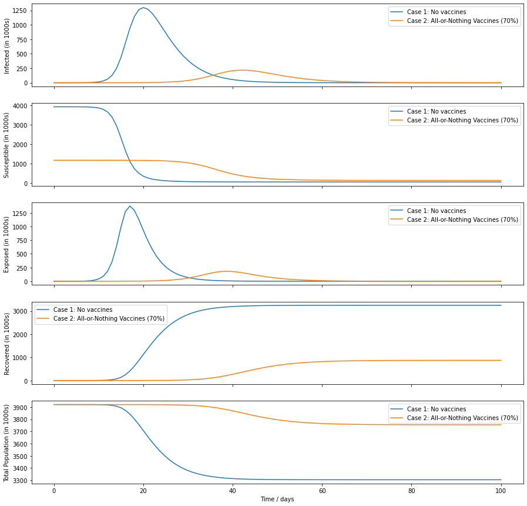

```python
import matplotlib.pyplot as plt
#plt.rc('axes.formatter', useoffset=False)

# Plotting subplots
fig, (ax1, ax2, ax3, ax4, ax5) = plt.subplots(5, sharex=True,figsize=(15,15))
plt.xlabel("Time / days")

ax1.plot(times,totalInfec1, label="Case 1: No vaccines")
ax1.plot(times,totalInfec2, label="Case 2: All-or-Nothing Vaccines (70%)")
ax1.set(ylabel="Infected (in 1000s)")
ax2.plot(times,totalSuscep1, label="Case 1: No vaccines")
ax2.plot(times,totalSuscep2, label="Case 2: All-or-Nothing Vaccines (70%)")
ax2.set(ylabel="Susceptible (in 1000s)")
ax3.plot(times,totalExp1, label="Case 1: No vaccines")
ax3.plot(times,totalExp2, label="Case 2: All-or-Nothing Vaccines (70%)")
ax3.set(ylabel="Exposed (in 1000s)")
ax4.plot(times,totalRec1, label="Case 1: No vaccines")
ax4.plot(times,totalRec2, label="Case 2: All-or-Nothing Vaccines (70%)")
ax4.set(ylabel="Recovered (in 1000s)")
ax5.plot(times, totalN1, label="Case 1: No vaccines")
ax5.plot(times, totalN2, label="Case 2: All-or-Nothing Vaccines (70%)")
ax5.set(ylabel="Total Population (in 1000s)")

ax1.legend(); ax2.legend(); ax3.legend(); ax4.legend(); ax5.legend();
```

The results look as expected of a SEIR model. Also, as expected, the use of vaccines significantly reduce infection rates, AND slow down the spread of the virus, as seen by the shift in the peak of infections towards a later time value.

## Part 2: Optimisation

Consider the scenario where there is not enough vaccines for the whole population e.g. 20% of the population as per COVAX's standard. Thus, the vaccination strategy must be optimized to minimize the number of deaths in the population. Thus, we want to minimize the function for number of deaths after the duration of the simulation, $D$, which is a function of the number of individuals vaccinated $V_i$ from group $i$. Not that the function only has to be dependent on 15 variables for our 16 age groups as they will be related. I.e.

$$D(V_1, V_2, \cdots V_{15}) = \text{number of deaths at the end of the simulation} \\ \sum_{i=1}^{16} V_i = \text{some constant value for total available vaccines, } V_{tot}$$

To optimize this, we will employ the Nelder-Mead algorithm for two reasons:

- Can accomodate high number of dimensions (in our case, 15)
- Requires only the function to be minimized/maximized, unlike gradient descent which requires the gradient as well. This is good as our function is difficult to be expressed analytically and thus the gradient would be highly difficult to calculate as well.

However, one problem is that the Nelder-Mead algorithm does not account for any constraints in the values for each dimension. Unfortunately, this is not what we want since for each age group $i$, we can vaccinate at most $N_i$ people and at least $0$ people from that age group. Thus, we will need to approach the situation with some modifications.

### Attempted Approach 1: Bounded Reflection and Expansion Steps

The first attempted approach is to modify the Nelder-Mead algorithm to check if any of the coordinate values of the vertices were beyond bounds. If they are beyond the bounds, the code will set the coordinate value that went beyond the bounds to be the upper/lower limit, depending on which one it exceeded. This is done for both the reflection and expansion steps, where the simplex will test a point that is outside the volume bounded by the simplex. Since the contraction and shrink step will definitely be within this bounded volume, there is no need to check that these steps are within the required limits.

```python
def NelderMeadMaximisationStepModified(functToUse, simplex, valueSimplex, lowerLim, UpperLim):

    dimension = len(valueSimplex)-1

    ## 1. Ordering Step
    simplexSortingIndices = valueSimplex.argsort()              # Finds the sequence of indices to sort the values
    valueSimplex          = valueSimplex[simplexSortingIndices] # Orders the values at the vertices by increasing value
    simplex               = simplex[:,simplexSortingIndices]    # Orders the vertices of the simplex by increasing function value

    ## 2. Centroid step
    centroid = np.sum(simplex[:,1:], axis=1)/dimension    # Finds the centroid of all vertices except worst performing one

    ## 3. Reflection step
    reflected = 2.0*centroid-simplex[:,0]    # Finds the reflected point

    ### MODIFICATION: accomodate unique bounds for each dimension
    if any(reflected < lowerLim) or any(reflected > upperLim):
        for i in range(dimension):
            if reflected[i] < lowerLim[i]:
                reflected[i] = lowerLim[i]
            elif reflected[i] > upperLim[i]:
                reflected[i] = upperLim[i]
            else:
                pass
    valueReflected = functToUse(reflected)   # Evaluates the function at the reflected point

    ## 4. Test reflected point
    if (valueReflected > valueSimplex[1] and valueReflected <= valueSimplex[-1]):
        simplex[:,0]    = reflected
        valueSimplex[0] = valueReflected
        return simplex, valueSimplex

    ## 5. Expansion step
    if (valueReflected > valueSimplex[-1]):
        expansion = -centroid+2.0*reflected      # Finds the expansion point
        ### MODIFICATION: accomodate unique bounds for each dimension
        if any(expansion < lowerLim) or any(expansion > upperLim):
            for i in range(dimension):
                if expansion[i] < lowerLim[i]:
                    expansion[i] = lowerLim[i]
                elif expansion[i] > upperLim[i]:
                    expansion[i] = upperLim[i]
                else:
                    pass
        valueExpansion = functToUse(expansion)   # Evaluates the function at the expansion point

    ## 6. Test expansion point
        if (valueExpansion > valueReflected):
            simplex[:,0]    = expansion
            valueSimplex[0] = valueExpansion
            return simplex, valueSimplex
        else:
            simplex[:,0]    = reflected
            valueSimplex[0] = valueReflected
            return simplex, valueSimplex

    ## 7. Contraction step
    ### As contraction will be within the legs (which should be within bounds), no need to check that it's within the bounds
    contraction = 0.5*centroid+0.5*simplex[:,0]    # Finds the contraction point
    valueContraction = functToUse(contraction)     # Evaluates the function at the contraction point

    ## 8. Test contraction step
    if (valueContraction > valueSimplex[0]):
        simplex[:,0]    = contraction
        valueSimplex[0] = valueContraction
        return simplex, valueSimplex

    ## 9. Shrink step
    ### Similarly, shrink step should be within bounds
    simplex[:,:-1]    = (0.5*simplex[:,:-1].T + 0.5*simplex[:,-1]).T
    valueSimplex[:-1] = functToUse(simplex[:,:-1])
    return simplex, valueSimplex


def NelderMeadMaximisationModified(functToUse, initialSimplex, positionToleranceAbsolute,
                               valueToleranceAbsolute, maxNumberIteration, lowerLim, upperLim):

    dimension = len(initialSimplex)

    simplex = np.copy(initialSimplex)    # Constructs initial coordinates of the simplex
    valueSimplex = functToUse(simplex)   # Evaluates the function to maximise on the vertices of the simplex

    newPosAverage   = np.sum(simplex,axis=1)/(dimension+1)
    newValueAverage = np.sum(valueSimplex)/(dimension+1)

    positionError  = 10 * abs(positionToleranceAbsolute) + 1
    valueError     = 10 * abs(valueToleranceAbsolute) + 1

    iteration = 0

    while (positionError > positionToleranceAbsolute and valueError > valueToleranceAbsolute) \
            and iteration < maxNumberIteration:

        iteration += 1
        oldPosAverage   = newPosAverage
        oldValueAverage = newValueAverage

        simplex, valueSimplex = NelderMeadMaximisationStepModified(functToUse, simplex, valueSimplex, lowerLim, upperLim)

        newPosAverage   = np.sum(simplex,axis=1)/(dimension+1)
        newValueAverage = np.sum(valueSimplex)/(dimension+1)

        positionError =np.linalg.norm(newPosAverage-oldPosAverage)
        valueError = np.abs(newValueAverage-oldValueAverage)

    return simplex[:,-1], valueSimplex[-1], iteration
```

We then can begin to construct our function $D$ based on the requirements for our algorithm. We need numDeaths to take an input of a vector containing our dependent variables. Inside the function, we employ RK4 using the skeleton of our solution from Part 1 to calculate the final population number at the end of the simulation. From there, we can obtain the number of deaths.

We also initialize all constants necessary for the function $D$.

#### Initial Conditions & Assumptions

- $I_i^0 =1/1000$ (seeded with 1 exposed person in each group, but note the numbers are in 1000s)
- $E_i^0 = 0$
- $R_i^0 = 0$
- $t^0=0$
- Assume that we only have enough vaccines for **20% of the population** (as per COVAX)
- Assume all vaccinated individuals benefit from the vaccination and gain immunity (all-or-nothing vaccines)

**Important Note:** we have to create a VECTORISED function as the Nelder-Mead algorithm requires the calculation of the function with a matrix (simplex), and also a single dimension input.

```python
def negNumDeaths(vaxVec):
    '''
    Vectorised function that returns an array for the negative number of deaths at the end of the simulation period.
    This function can take in a 2-dimensional vector of inputs to calculate multiple trials of vaccine strategies
    (see paramaters below).
    Since we want to MINIMIZE the function, we need to maximize the negative of the number of deaths with NM maximization algo,
    thus we return the negative value of total number of deaths.

    Parameters
    ---
    vaxVec  : numpy array
              the array of the number of vaccinated individuals from each age group.
              this array can be 2-dimensional, with the rows corresponding to each of the 15 age groups, while the
              columns correspond to each trial to be calculated.

    Returns
    ---
    totNegDeath : numpy array
               total negative number of deaths from all age groups at the end of the simulation period for all trials
    '''
    # negNumDeaths Inputs: Constant Initial Conditions
    Ntot        = 3920.26      # population number
    vaxAvail    = 0.2 * Ntot   # vaccines available

    initIOpt    = np.ones(16) /1000
    initNOpt    = np.array([N1, N2, N3, N4, N5, N6, N7, N8, N9, N10, N11, N12, N13, N14, N15, N16])
    initEOpt    = np.zeros(16)
    initROpt    = np.zeros(16)

    if(np.ndim(vaxVec) == 1):
        # If the input is only 1 dimension
        vaxVecMod = np.append(vaxVec, vaxAvail - np.sum(vaxVec)) # modified vector to include last age group

        # RK4 Inputs: Initial Condition
        initSOpt    = np.array([N1, N2, N3, N4, N5, N6, N7, N8, N9, N10, N11, N12, N13, N14, N15, N16]) - initIOpt - vaxVecMod
        initCondOpt = np.concatenate((initIOpt, initSOpt, initEOpt, initROpt, initNOpt))

        # Solving Using RK4
        times, solutOpt = rungeKutta4(operator, initCondOpt, initTime, finalTime, numSteps)

        # Retrieving Total Number of deaths at the end of the simulation from solution
        totDeath = Ntot - np.sum(solutOpt[-1,64:80])   # Total initial population minus total remaining population

    else:
        # Creating A Vectorised Function for 2 dimensional input
        numVectors = np.shape(vaxVec)[1] # shape[1] gives the number of elements in the second dimension, i.e. num columns
        totDeath   = np.zeros(numVectors)

        for i in range(numVectors):
            vaxVecMod   = np.append(vaxVec[:,i], vaxAvail - np.sum(vaxVec[:,i]))

            # RK4 Inputs: Initial Condition
            initSOpt    = np.array([N1, N2, N3, N4, N5, N6, N7, N8, N9, N10, N11, N12, N13, N14, N15, N16]) - initIOpt - vaxVecMod
            initCondOpt = np.concatenate((initIOpt, initSOpt, initEOpt, initROpt, initNOpt))

            # Solving Using RK4
            times, solutOpt = rungeKutta4(operator, initCondOpt, initTime, finalTime, numSteps)

            # Retrieving Total Number of deaths at the end of the simulation from solution
            totDeath[i] = Ntot - np.sum(solutOpt[-1,64:80])

    totNegDeath = - totDeath
    return totNegDeath
```

We can check that this function is indeed vectorised and will work for both single trial of vaccination data or several trials.

```python
testMatrix = np.array([[36.6, 100, 100, 100, 100, 100, 100, 100, 100, 100, 100, 100, 100, 100, 100, 250], \
                       [39.7, 200, 100, 200, 100, 200, 100, 200, 100, 200, 100, 200, 100, 200, 100, 250], \
                       [41.2, 100, 300, 500, 50, 10, 60, 70, 50, 100, 50, 10, 10, 10, 50, 250], \
                       [43.0, 100, 300, 200, 50, 50, 60, 10, 50, 200, 50, 10, 10, 10, 50, 250], \
                       [48.9, 100, 300, 500, 50, 50, 120, 10, 50, 200, 50, 10, 10, 10, 300, 250], \
                       [57.4, 100, 300, 100, 100, 10, 150, 10, 50, 200, 50, 200, 10, 10, 200, 250], \
                       [59.5, 700, 300, 100, 200, 10, 400, 10, 50, 200, 50, 200, 10, 10, 50, 250], \
                       [59.9, 400, 300, 400, 300, 100, 500, 10, 50, 100, 100, 100, 10, 10, 10, 250], \
                       [59.8, 200, 300, 20, 400, 800, 100, 10, 50, 50, 100, 50, 10, 100, 10, 250], \
                       [62.3, 200, 300, 400, 500, 600, 700, 800, 900, 1000, 1100, 1200, 1300, 1400, 1500, 250], \
                       [59.2, 300, 300, 700, 600, 800, 800, 100, 900, 50, 200, 500, 500, 500, 10, 250], \
                       [61.1, 200, 300, 400, 500, 600, 700, 800, 900, 1000, 1100, 1200, 1300, 1400, 1500, 250], \
                       [56.9, 200, 300, 200, 700, 100, 100, 200, 50, 50, 100, 100, 100, 10, 5, 250], \
                       [45.8, 700, 300, 50, 100, 200, 10, 100, 50, 50, 100, 10, 100, 10, 5, 250], \
                       [34.0, 50, 50, 50, 100, 100, 10, 600, 50, 50, 100, 10, 100, 100, 5, 250]
                          ])

print(negNumDeaths(testMatrix))
print(negNumDeaths(testMatrix[:,5]))
```

```
[-489.47523787 -323.66492278  -11.68615431 -388.27240389 -345.83895328
 -393.69246421 -402.55417769 -308.23381581 -417.47636438 -372.0617902
 -359.59412565 -475.47858196 -420.73981923 -485.73231933 -488.28750099
 -217.45866991]
-393.6924642125168
```

We can now move towards using our algorithm to optimize the vaccination strategy. We first initialize all other input constants, as well as the simplex matrix required for our problem. This matrix that contains the positions for all the 16 vertices of the simplex. Then we can call our function to solve. Note that our initial simplex must have points also within our constraints.

```python
# Nelder-Mead Inputs
positionToleranceAbsolute = 0.0001
valueToleranceAbsolute = 0.0001
maxNumberIteration = 1000

lowerLim = np.zeros(15)
upperLim = np.array([N1, N2, N3, N4, N5, N6, N7, N8, N9, N10, N11, N12, N13, N14, N15])

initialSimplex = np.array([[36.616, 100, 50, 10, 50, 10, 10, 10, 10, 10, 10, 10, 0, 0, 70, 70], \
                           [39.748, 10, 100, 10, 50, 10, 0, 5, 0, 100, 20, 10, 0, 10, 2, 50], \
                           [41.278, 10, 100, 5, 50, 20, 0, 5, 0, 20, 90, 10, 0, 20, 2, 110], \
                           [43.046, 100, 100, 5, 10, 20, 10, 5, 10, 20, 10, 5, 0, 30, 5, 100], \
                           [48.908, 100, 100, 5, 200, 30, 0, 5, 20, 100, 20, 5, 0, 40, 5, 90], \
                           [57.4, 10, 50, 5, 100, 30, 30, 10, 50, 20, 50, 5, 0, 50, 100, 80], \
                           [59.56, 10, 50, 40, 10, 40, 40, 50, 200, 20, 40, 20, 0, 60, 300, 70], \
                           [59.904, 10, 10, 50, 10, 40, 20, 20, 10, 20, 100, 20, 0, 70, 200, 60], \
                           [59.858, 10, 10, 10, 10, 50, 20, 100, 10, 20, 20, 70, 0, 80, 100, 50], \
                           [62.348, 100, 10, 200, 200, 300, 300, 200, 100, 100, 20, 20, 300, 90, 0, 40], \
                           [59.214, 100, 10, 100, 10, 100, 200, 100, 100, 200, 200, 100, 290, 100, 0, 30], \
                           [61.166, 100, 10, 200, 15, 10, 100, 50, 100, 100, 50, 300, 100, 110, 0, 20], \
                           [56.926, 50, 50, 100, 15, 20, 20, 50, 100, 20, 50, 60, 50, 120, 0, 10], \
                           [45.88, 50, 50, 10, 20, 40, 10, 100, 10, 10, 50, 60, 10, 2, 0, 0], \
                           [34.002, 10, 50, 10, 25, 30, 10, 50, 10, 20, 50, 70, 20, 2, 0, 0], \
                          ])

# Optimize Using Nelder Mead Inputs
positionMax, valueMax, iteratNumber = NelderMeadMaximisationModified(negNumDeaths, initialSimplex, positionToleranceAbsolute,
                               valueToleranceAbsolute, maxNumberIteration, lowerLim, upperLim)

print(positionMax, valueMax, iteratNumber)
```

```
[ 59.5618474  188.9360023  195.43810661 209.32852506 225.06700355
 253.28485823 289.29624779 297.94158345 289.78311528 311.39378158
 286.69247382 227.94466734 274.33469939 209.37098206  91.72865362] -9.262630666805762 1000
```

```python
np.sum(positionMax)
```

```
3410.102547463873
```

The algorithm runs fine. **However, there is another problem.** Notice that the sum of all vaccinated individuals `np.sum(positionMax)` is a number much greater than our actual available vaccines (which is only around 784). Recall that deaths is a function of the number of vaccinated individuals for 15 age groups, as the last group will be dependent on the other 15 due to the constraint. Unfortunately, while this modified algorithm can account for the 15 dimensions to be within the bounds, it cannot account for the last age group. This means that the last age group can be any positive or negative number, which is what has happened here. The algorithm outputs a result where the last age group has a large negative number of vaccinated individuals, which does not make sense.

One way to resolve this might be to check that the sum of all the vaccinated individuals (i.e. sum the coordinates of a simplex 'leg') to check that it is within the maximum vaccines available. However, even if this approach is taken, it's difficult to tell the algorithm how to proceed for the case that it does exceed. Thus, a new solution might more be viable.

### Attempted Approach 2: Modified Function with Penalty

Another approach would be to instead modify our function that goes through the normal Nelder-Mead algorithm. We can give the number of deaths a penalty for values of $V_i$ that goes outside of the boundaries. In this case, we want to make the negative number of deaths even more negative for exceeding the bounds. Thus we can modify the function with a heaviside function:

`penalty = 3920*(np.sum(np.heaviside(-vaxVecMod,0.) + np.heaviside(vaxVecMod-initNOpt,0.), axis=0))`

**Note:** The first heaviside function ensures that the vaccination rates are more than 0. The second heaviside function ensures that vaccination rates (including the 16th age group) are less than the number of available people per age group. Since we use `vaxVecMod` that includes the 16th age group calculated based on the constraints on the number of vaccinations, we do not need an additional heaviside function to check that our total vaccinations are within the limits to the total number of vaccines we have as it will already be accounted for.

We sum them all and multiply it by the total population number that will be added to the number of deaths in the event that they cross the boundaries set. Total population number is chosen to be the factor multiplied since we are guaranteed that this will be greater than the number of deaths possible.

#### Initial Conditions & Assumptions

- $I_i^0 =1/1000$ (seeded with 1 exposed person in each group, but note the numbers are in 1000s)
- $E_i^0 = 0$
- $R_i^0 = 0$
- $t^0=0$
- $S_i^0 = N_i^0 - I_i^0 - V_i$ where $V_i$ is the number of vaccinated individuals in age group $i$
- Assume that we only have enough vaccines for **20% of the population** (as per COVAX)

```python
def negNumDeathsWithPenalty(vaxVec):
    '''
    Vectorised function that returns an array for the negative number of deaths at the end of the simulation period.
    This function can take in a 2-dimensional vector of inputs to calculate multiple trials of vaccine strategies
    (see paramaters below).
    Since we want to MINIMIZE the function, we need to maximize the negative of the number of deaths with NM maximization algo,
    thus we return the negative value of total number of deaths.

    Parameters
    ---
    vaxVec  : numpy array
              the array of the number of vaccinated individuals from each age group.
              this array can be 2-dimensional, with the rows corresponding to each of the 15 age groups, while the
              columns correspond to each trial to be calculated.

    Returns
    ---
    modifiedTotNegDeath : numpy array
               total negative number of deaths from all age groups at the end of the simulation period for all trials
               WITH a penalty in the event that vaxVec has elements that are outside the constraints we have
    '''
    # negNumDeaths Inputs: Constant Initial Conditions
    Ntot        = 3920.26      # population number
    vaxAvail    = 0.2 * Ntot   # vaccines available

    initIOpt    = np.ones(16) /1000
    initNOpt    = np.array([N1, N2, N3, N4, N5, N6, N7, N8, N9, N10, N11, N12, N13, N14, N15, N16])
    initEOpt    = np.zeros(16)
    initROpt    = np.zeros(16)

    if(np.ndim(vaxVec) == 1):
        # If the input is only 1 dimension
        vaxVecMod = np.append(vaxVec, vaxAvail - np.sum(vaxVec)) # modified vector to include last age group

        # RK4 Inputs: Initial Condition
        initSOpt    = np.array([N1, N2, N3, N4, N5, N6, N7, N8, N9, N10, N11, N12, N13, N14, N15, N16]) - initIOpt - vaxVecMod
        initCondOpt = np.concatenate((initIOpt, initSOpt, initEOpt, initROpt, initNOpt))
        # Solving Using RK4
        times, solutOpt = rungeKutta4(operator, initCondOpt, initTime, finalTime, numSteps)

        # Retrieving Total Number of deaths at the end of the simulation from solution
        totDeath = Ntot - np.sum(solutOpt[-1,64:80])   # Total initial population minus total remaining population

        ## MODIFICATION: penalty
        # Note that since vaxVecMod includes the final age group which is calculated based on the constraint
        # to the number of vaccinations available, we can just use 2 heaviside functions.
        penalty = Ntot * (np.sum(np.heaviside(-vaxVecMod,0.) + np.heaviside(vaxVecMod-initNOpt,0.), axis=0))
        modifiedTotNegDeath = -totDeath - penalty

    else:
        # Creating A Vectorised Function for 2 dimensional input
        numVectors = np.shape(vaxVec)[1] # shape[1] gives the number of elements in the second dimension, i.e. num columns
        totDeath   = np.zeros(numVectors)
        penalty    = np.zeros(numVectors)

        for i in range(numVectors):
            vaxVecMod   = np.append(vaxVec[:,i], vaxAvail - np.sum(vaxVec[:,i]))

            # RK4 Inputs: Initial Condition
            initSOpt    = np.array([N1, N2, N3, N4, N5, N6, N7, N8, N9, N10, N11, N12, N13, N14, N15, N16]) - initIOpt - vaxVecMod
            initCondOpt = np.concatenate((initIOpt, initSOpt, initEOpt, initROpt, initNOpt))
            # Solving Using RK4
            times, solutOpt = rungeKutta4(operator, initCondOpt, initTime, finalTime, numSteps)

            # Retrieving Total Number of deaths at the end of the simulation from solution
            totDeath[i] = Ntot - np.sum(solutOpt[-1,64:80])

            ## MODIFICATION: penalty
            penalty[i] = Ntot * (np.sum(np.heaviside(-vaxVecMod,0.) + np.heaviside(vaxVecMod-initNOpt,0.), axis=0))
            modifiedTotNegDeath = -np.sum([totDeath, penalty], axis=0)

    return modifiedTotNegDeath
```

Just as we did in the previous section, we will check once more than our modified function still works as a vectorised function should. Further, we check that the penalty works suitably by comparing our results from this check to the results we found from the previous check using the old `negNumDeaths` function. Note that the first element remains the same between the two matrices, implying our function works as expected, since the chosen vaccination rates for the first column in `testMatrix` is within all our constraints.

```python
testMatrix = np.array([[36.6, 100, 100, 100, 100, 100, 100, 100, 100, 100, 100, 100, 100, 100, 100, 250], \
                       [39.7, 200, 100, 200, 100, 200, 100, 200, 100, 200, 100, 200, 100, 200, 100, 250], \
                       [41.2, 100, 300, 500, 50, 10, 60, 70, 50, 100, 50, 10, 10, 10, 50, 250], \
                       [43.0, 100, 300, 200, 50, 50, 60, 10, 50, 200, 50, 10, 10, 10, 50, 250], \
                       [48.9, 100, 300, 500, 50, 50, 120, 10, 50, 200, 50, 10, 10, 10, 300, 250], \
                       [57.4, 100, 300, 100, 100, 10, 150, 10, 50, 200, 50, 200, 10, 10, 200, 250], \
                       [59.5, 700, 300, 100, 200, 10, 400, 10, 50, 200, 50, 200, 10, 10, 50, 250], \
                       [59.9, 400, 300, 400, 300, 100, 500, 10, 50, 100, 100, 100, 10, 10, 10, 250], \
                       [59.8, 200, 300, 20, 400, 800, 100, 10, 50, 50, 100, 50, 10, 100, 10, 250], \
                       [62.3, 200, 300, 400, 500, 600, 700, 800, 900, 1000, 1100, 1200, 1300, 1400, 1500, 250], \
                       [59.2, 300, 300, 700, 600, 800, 800, 100, 900, 50, 200, 500, 500, 500, 10, 250], \
                       [61.1, 200, 300, 400, 500, 600, 700, 800, 900, 1000, 1100, 1200, 1300, 1400, 1500, 250], \
                       [56.9, 200, 300, 200, 700, 100, 100, 200, 50, 50, 100, 100, 100, 10, 5, 250], \
                       [45.8, 700, 300, 50, 100, 200, 10, 100, 50, 50, 100, 10, 100, 10, 5, 250], \
                       [34.0, 50, 50, 50, 100, 100, 10, 600, 50, 50, 100, 10, 100, 100, 5, 250]
                          ])

print(negNumDeathsWithPenalty(testMatrix))
print(negNumDeathsWithPenalty(testMatrix[:,5]))
```

```
[  -489.47523787 -23845.22492278 -43134.54615431 -31750.35240389
 -27787.65895328 -23915.25246421 -23924.11417769 -19909.53381581
 -16098.51636438 -16053.1017902  -12120.37412565 -20076.77858196
 -16101.77981923 -20087.03231933 -16169.32750099 -31579.53866991]
-23915.252464212517
```

We can now import the regular Nelder-Mead algorithm, and once more attempt at a solution.

```python
def NelderMeadMaximisationStep(functToUse, simplex, valueSimplex):

    dimension = len(valueSimplex)-1

    ## 1. Ordering Step
    simplexSortingIndices = valueSimplex.argsort()              # Finds the sequence of indices to sort the values
    valueSimplex          = valueSimplex[simplexSortingIndices] # Orders the values at the vertices by increasing value
    simplex               = simplex[:,simplexSortingIndices]    # Orders the vertices of the simplex by increasing function value

    ## 2. Centroid step
    centroid = np.sum(simplex[:,1:], axis=1)/dimension    # Finds the centroid of all vertices except worst performing one

    ## 3. Reflection step
    reflected = 2.0*centroid-simplex[:,0]    # Finds the reflected point
    valueReflected = functToUse(reflected)   # Evaluates the function at the reflected point

    ## 4. Test reflected point
    if (valueReflected > valueSimplex[1] and valueReflected <= valueSimplex[-1]):
        simplex[:,0]    = reflected
        valueSimplex[0] = valueReflected
        return simplex, valueSimplex

    ## 5. Expansion step
    if (valueReflected > valueSimplex[-1]):
        expansion = -centroid+2.0*reflected      # Finds the expansion point
        valueExpansion = functToUse(expansion)   # Evaluates the function at the expansion point

    ## 6. Test expansion point
        if (valueExpansion > valueReflected):
            simplex[:,0]    = expansion
            valueSimplex[0] = valueExpansion
            return simplex, valueSimplex
        else:
            simplex[:,0]    = reflected
            valueSimplex[0] = valueReflected
            return simplex, valueSimplex

    ## 7. Contraction step
    contraction = 0.5*centroid+0.5*simplex[:,0]    # Finds the contraction point
    valueContraction = functToUse(contraction)     # Evaluates the function at the contraction point

    ## 8. Test contraction step
    if (valueContraction > valueSimplex[0]):
        simplex[:,0]    = contraction
        valueSimplex[0] = valueContraction
        return simplex, valueSimplex

    ## 9. Shrink step
    simplex[:,:-1]    = (0.5*simplex[:,:-1].T + 0.5*simplex[:,-1]).T
    valueSimplex[:-1] = functToUse(simplex[:,:-1])
    return simplex, valueSimplex


def NelderMeadMaximisation(functToUse, initialSimplex, positionToleranceAbsolute,
                               valueToleranceAbsolute, maxNumberIteration):

    dimension = len(initialSimplex)

    simplex = np.copy(initialSimplex)    # Constructs initial coordinates of the simplex
    valueSimplex = functToUse(simplex)   # Evaluates the function to maximise on the vertices of the simplex

    newPosAverage   = np.sum(simplex,axis=1)/(dimension+1)
    newValueAverage = np.sum(valueSimplex)/(dimension+1)

    positionError  = 10 * abs(positionToleranceAbsolute) + 1
    valueError     = 10 * abs(valueToleranceAbsolute) + 1

    iteration = 0

    while (positionError > positionToleranceAbsolute and valueError > valueToleranceAbsolute) \
            and iteration < maxNumberIteration:

        iteration += 1
        oldPosAverage   = newPosAverage
        oldValueAverage = newValueAverage

        simplex, valueSimplex = NelderMeadMaximisationStep(functToUse, simplex, valueSimplex)

        newPosAverage   = np.sum(simplex,axis=1)/(dimension+1)
        newValueAverage = np.sum(valueSimplex)/(dimension+1)

        positionError =np.linalg.norm(newPosAverage-oldPosAverage)
        valueError = np.abs(newValueAverage-oldValueAverage)

    return simplex[:,-1], valueSimplex[-1], iteration
```

```python
# Nelder-Mead Inputs
positionToleranceAbsolute = 0.000001
valueToleranceAbsolute = 0.000001
maxNumberIteration = 10000

initialSimplex = np.array([[36.616, 100, 50, 10, 50, 10, 10, 10, 10, 10, 10, 10, 0, 0, 70, 70], \
                           [39.748, 10, 100, 10, 50, 10, 0, 5, 0, 100, 20, 10, 0, 10, 2, 50], \
                           [41.278, 10, 100, 5, 50, 20, 0, 5, 0, 20, 90, 10, 0, 20, 2, 110], \
                           [43.046, 100, 100, 5, 10, 20, 10, 5, 10, 20, 10, 5, 0, 30, 5, 100], \
                           [48.908, 100, 100, 5, 200, 30, 0, 5, 20, 100, 20, 5, 0, 40, 5, 90], \
                           [57.4, 10, 50, 5, 100, 30, 30, 10, 50, 20, 50, 5, 0, 50, 100, 80], \
                           [59.56, 10, 50, 40, 10, 40, 40, 50, 200, 20, 40, 20, 0, 60, 300, 70], \
                           [59.904, 10, 10, 50, 10, 40, 20, 20, 10, 20, 100, 20, 0, 70, 200, 60], \
                           [59.858, 10, 10, 10, 10, 50, 20, 100, 10, 20, 20, 70, 0, 80, 100, 50], \
                           [62.348, 100, 10, 200, 200, 300, 300, 200, 100, 100, 20, 20, 300, 90, 0, 40], \
                           [59.214, 100, 10, 100, 10, 100, 200, 100, 100, 200, 200, 100, 290, 100, 0, 30], \
                           [61.166, 100, 10, 200, 15, 10, 100, 50, 100, 100, 50, 300, 100, 110, 0, 20], \
                           [56.926, 50, 50, 100, 15, 20, 20, 50, 100, 20, 50, 60, 50, 120, 0, 10], \
                           [45.88, 50, 50, 10, 20, 40, 10, 100, 10, 10, 50, 60, 10, 2, 0, 0], \
                           [34.002, 10, 50, 10, 25, 30, 10, 50, 10, 20, 50, 70, 20, 2, 0, 0], \
                          ])

# Optimize Using Nelder Mead Inputs
positionMax, valueMax, iteratNumber = NelderMeadMaximisation(negNumDeathsWithPenalty, initialSimplex, positionToleranceAbsolute,
                               valueToleranceAbsolute, maxNumberIteration)

print(positionMax, valueMax, iteratNumber)
```

```
[7.58283503e-01 9.93652838e-04 7.11219988e+00 2.40182537e+01
 4.67797516e+01 1.67180376e-03 8.35611552e-04 9.59176626e+01
 5.68109646e+01 3.73678095e-02 8.65771888e+01 2.21340208e+02
 2.40040894e+02 4.54188135e+00 3.05867082e-05] -484.5569482727278 1058
```

```python
Ntot     = 3920.26      # population number
vaxAvail = 0.2 * Ntot   # vaccines available

optimisedVaxRates = np.append(positionMax, vaxAvail - np.sum(positionMax))
np.set_printoptions(suppress=True) # Print without scientific notation
optimisedVaxRates
```

```
array([  0.7582835 ,   0.00099365,   7.11219988,  24.01825365,
        46.77975159,   0.0016718 ,   0.00083561,  95.91766257,
        56.81096459,   0.03736781,  86.57718878, 221.34020817,
       240.04089449,   4.54188135,   0.00003059,   0.11381196])
```

### Results and Comparing Cases

The data has been re-represented in the table below for ease of reading.

| Age Group | Age Index, $i$ | Total Population in Age Group in 1000s | Vaccinated Individuals in 1000s (3 d.p.) |
| --- | --- | --- | --- |
| 0-4 | 1 | 183.080 | 0.758 |
| 5-9 | 2 | 198.740 | 0.001 |
| 10-14 | 3 | 206.390 | 7.112 |
| 15-19 | 4 | 215.230 | 24.018 |
| 20-24 | 5 | 244.540 | 46.780 |
| 25-29 | 6 | 287.000 | 0.002 |
| 30-34 | 7 | 297.800 | 0.001 |
| 35-39 | 8 | 299.520 | 95.918 |
| 40-44 | 9 | 299.290 | 56.811 |
| 45-49 | 10 | 311.740 | 0.037 |
| 50-54 | 11 | 296.070 | 86.577 |
| 55-59 | 12 | 305.830 | 221.340 |
| 60-64 | 13 | 284.630 | 240.041 |
| 65-69 | 14 | 229.400 | 4.542 |
| 70-74 | 15 | 170.010 | 0.000 |
| 75-79 | 16 | 90.990 | 0.114 |

With our data, we can now plot to compare across three cases:

- No vaccinations (Case 1)
- Flat rate of vaccinations at 20% per age group (Case 3)
- Optimized vaccination rates as per Nelder-Mead algorithm solution (Case 4)

```python
# Case 3: 20% Flat Vaccinations
initS3    = 0.8 * np.array([N1, N2, N3, N4, N5, N6, N7, N8, N9, N10, N11, N12, N13, N14, N15, N16]) - initE1 - initI1
initCond3 = np.concatenate((initI1, initS3, initE1, initR1, initN1)) # Re-use the init cond for case 1 for everything except S since it remains constant

times, solut3 = rungeKutta4(operator, initCond3, initTime, finalTime, numSteps)

# Case 4: Optimised Vaccinations
initS4    = np.array([N1, N2, N3, N4, N5, N6, N7, N8, N9, N10, N11, N12, N13, N14, N15, N16]) - initI1 - optimisedVaxRates
initCond4 = np.concatenate((initI1, initS4, initE1, initR1, initN1))

times, solut4 = rungeKutta4(operator, initCond4, initTime, finalTime, numSteps)
```

```
The total number of deaths (in 1000s) for each case are: 616.6408075050804 (Case 1), 489.4377126206573 (Case 3), 484.5569482727278 (Case 4).
```

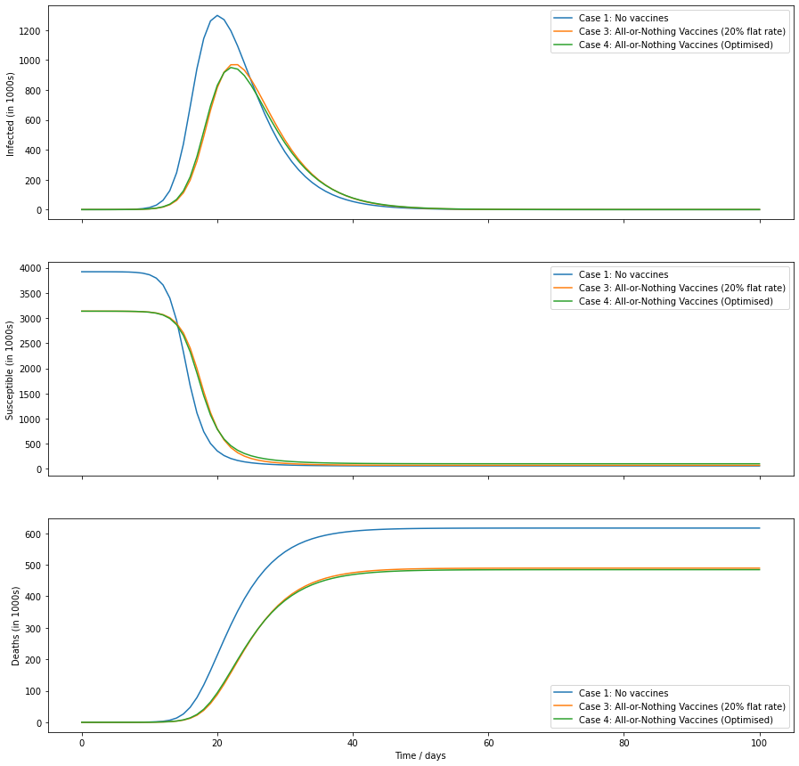

```python
# Data To Plot
totalInfec3  = np.sum(solut3[:,0:16], axis=1)   # Infectious population at time t
totalSuscep3 = np.sum(solut3[:,16:32], axis=1)  # Susceptible population at time t
totalExp3    = np.sum(solut3[:,32:48], axis=1)  # Exposed population at time t
totalRec3    = np.sum(solut3[:,48:64], axis=1)  # Recovered population at time t
totalN3      = np.sum(solut3[:,64:80], axis=1)  # Remaining population number at time t

totalInfec4  = np.sum(solut4[:,0:16], axis=1)
totalSuscep4 = np.sum(solut4[:,16:32], axis=1)
totalExp4    = np.sum(solut4[:,32:48], axis=1)
totalRec4    = np.sum(solut4[:,48:64], axis=1)
totalN4      = np.sum(solut4[:,64:80], axis=1)

# Plotting
import matplotlib.pyplot as plt
#plt.rc('axes.formatter', useoffset=False)

fig, (ax1, ax2, ax3) = plt.subplots(3, sharex=True,figsize=(15,15))
plt.xlabel("Time / days")

ax1.plot(times,totalInfec1, label="Case 1: No vaccines")
ax1.plot(times,totalInfec3, label="Case 3: All-or-Nothing Vaccines (20% flat rate)")
ax1.plot(times,totalInfec4, label="Case 4: All-or-Nothing Vaccines (Optimised)")
ax1.set(ylabel="Infected (in 1000s)")
ax2.plot(times,totalSuscep1, label="Case 1: No vaccines")
ax2.plot(times,totalSuscep3, label="Case 3: All-or-Nothing Vaccines (20% flat rate)")
ax2.plot(times,totalSuscep4, label="Case 4: All-or-Nothing Vaccines (Optimised)")
ax2.set(ylabel="Susceptible (in 1000s)")
ax3.plot(times, Ntot-totalN1, label="Case 1: No vaccines")
ax3.plot(times, Ntot-totalN3, label="Case 3: All-or-Nothing Vaccines (20% flat rate)")
ax3.plot(times, Ntot-totalN4, label="Case 4: All-or-Nothing Vaccines (Optimised)")
ax3.set(ylabel="Deaths (in 1000s)")

ax1.legend(); ax2.legend(); ax3.legend();

print('The total number of deaths (in 1000s) for each case are: {} (Case 1), {} (Case 3), {} (Case 4).'.format(Ntot-totalN1[-1], Ntot-totalN3[-1], Ntot-totalN4[-1]))
```

Here, we have successfully optimised the vaccination plan. And that concludes this project.